## Exploratory Data Analysis on White Wine dataset

The aim of the project is to analyze different parameters affecting the quality of the white wine. We are given a White wine dataset and we must perform uni abd bivariate data analysis to depict how a content affects the quality. My project includes univarite analysis where i plot the featuresto check whether the data is normailzed or not.

# bivariate:

The feature of data set is as follows. There are total of 12 variables .

[figure not shown]

## Attribute information

1. fixed acidity
2. volatile acidity
3. citric acid
4. residual sugar
5. chlorides
6. free sulfur dioxide
7. total sulfur dioxide
8. density
9. pH
10. sulphates
11. alcohol

    Output variable
12. quality (score between 0 and 10)

```python
import numpy as np
import pandas as pd
import matplotlib.pyplot as plt
import seaborn as sns
%matplotlib inline
```

### Importing the dataset

```python
df=pd.read_csv("https://archive.ics.uci.edu/ml/machine-learning-databases/wine-quality/winequality-white.csv",delimiter=";")
```

Viewing first few rows to check whether the data is imported properly or not.

```python
df.head()
```

|  | fixed acidity | volatile acidity | citric acid | residual sugar | chlorides | free sulfur dioxide | total sulfur dioxide | density | pH | sulphates | alcohol | quality |
| --- | --- | --- | --- | --- | --- | --- | --- | --- | --- | --- | --- | --- |
| 0 | 7.0 | 0.27 | 0.36 | 20.7 | 0.045 | 45.0 | 170.0 | 1.0010 | 3.00 | 0.45 | 8.8 | 6 |
| 1 | 6.3 | 0.30 | 0.34 | 1.6 | 0.049 | 14.0 | 132.0 | 0.9940 | 3.30 | 0.49 | 9.5 | 6 |
| 2 | 8.1 | 0.28 | 0.40 | 6.9 | 0.050 | 30.0 | 97.0 | 0.9951 | 3.26 | 0.44 | 10.1 | 6 |
| 3 | 7.2 | 0.23 | 0.32 | 8.5 | 0.058 | 47.0 | 186.0 | 0.9956 | 3.19 | 0.40 | 9.9 | 6 |
| 4 | 7.2 | 0.23 | 0.32 | 8.5 | 0.058 | 47.0 | 186.0 | 0.9956 | 3.19 | 0.40 | 9.9 | 6 |

```python
df.shape
```

```
(4898, 12)
```

Here is the size of the dataset.

```python
df.size
```

```
58776
```

Use describe function to check the statistical data.

```python
df.describe(include='all')
```

|  | fixed acidity | volatile acidity | citric acid | residual sugar | chlorides | free sulfur dioxide | total sulfur dioxide | density | pH | sulphates | alcohol | quality |
| --- | --- | --- | --- | --- | --- | --- | --- | --- | --- | --- | --- | --- |
| count | 4898.000000 | 4898.000000 | 4898.000000 | 4898.000000 | 4898.000000 | 4898.000000 | 4898.000000 | 4898.000000 | 4898.000000 | 4898.000000 | 4898.000000 | 4898.000000 |
| mean | 6.854788 | 0.278241 | 0.334192 | 6.391415 | 0.045772 | 35.308085 | 138.360657 | 0.994027 | 3.188267 | 0.489847 | 10.514267 | 5.877909 |
| std | 0.843868 | 0.100795 | 0.121020 | 5.072058 | 0.021848 | 17.007137 | 42.498065 | 0.002991 | 0.151001 | 0.114126 | 1.230621 | 0.885639 |
| min | 3.800000 | 0.080000 | 0.000000 | 0.600000 | 0.009000 | 2.000000 | 9.000000 | 0.987110 | 2.720000 | 0.220000 | 8.000000 | 3.000000 |
| 25% | 6.300000 | 0.210000 | 0.270000 | 1.700000 | 0.036000 | 23.000000 | 108.000000 | 0.991723 | 3.090000 | 0.410000 | 9.500000 | 5.000000 |
| 50% | 6.800000 | 0.260000 | 0.320000 | 5.200000 | 0.043000 | 34.000000 | 134.000000 | 0.993740 | 3.180000 | 0.470000 | 10.400000 | 6.000000 |
| 75% | 7.300000 | 0.320000 | 0.390000 | 9.900000 | 0.050000 | 46.000000 | 167.000000 | 0.996100 | 3.280000 | 0.550000 | 11.400000 | 6.000000 |
| max | 14.200000 | 1.100000 | 1.660000 | 65.800000 | 0.346000 | 289.000000 | 440.000000 | 1.038980 | 3.820000 | 1.080000 | 14.200000 | 9.000000 |

```python
df.isnull().sum()
```

```
fixed acidity           0
volatile acidity        0
citric acid             0
residual sugar          0
chlorides               0
free sulfur dioxide     0
total sulfur dioxide    0
density                 0
pH                      0
sulphates               0
alcohol                 0
quality                 0
dtype: int64
```

## Dataset Description

We are using White wine data set made on Portuguese "Vinho Verde " wine. The data set is available at [This link](http://www3.dsi.uminho.pt/pcortez/wine/) The size of the data is 4898. It contains 11 features and 1 output column. The chemical properties like fixed acidity, volatile acidity , density and pH are all continuous data. The ouput , quality in a ordinal variable with ranking between 1-10. The data set contains no null values.

### Univariate Analysis

Univariate analysis includes analysis of single features. It is used to check whether the feature is normally distributed or not and to find the outliers.

## Quality : Countplot

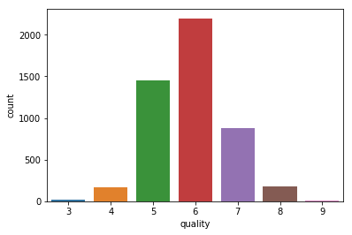

```python
sns.countplot(x='quality', data=df)
```

From this plot we came to know that:

1. The mean quality is the one with highest number of sample.
2. Followed by 5 and 7 rated qulity wines in terms of count.
3. Best quality wines are the lest present in the sample.

## Fixed acidity : Count plot

```
Text(0,0.5,'count')
```

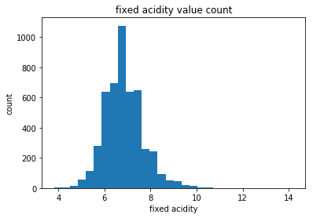

```python
plt.hist(df['fixed acidity'], bins=30, )
plt.title('fixed acidity value count')
plt.xlabel('fixed acidity')
plt.ylabel('count')
```

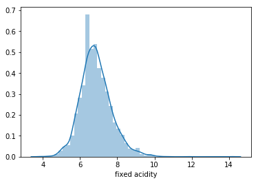

```python
sns.distplot(df['fixed acidity'])
```

1. Continous
2. Normal in nature.
3. It can be inferred from the above plot that fixed acidity value lies between 3.8 and 14.2 g / dm^3.

## Volatile acid: Count plot

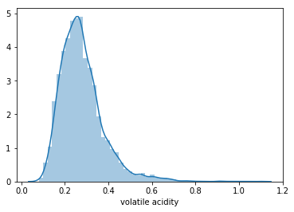

```python
sns.distplot(df['volatile acidity'])
```

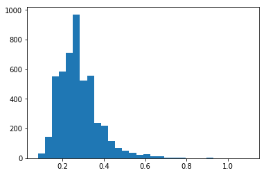

```python
plt.hist(df['volatile acidity'],bins=30)
```

1. Outliers present.
2. Continous distribution.
3. Long positive tails.
4. Right skewed.

## Citric acid : Countplot

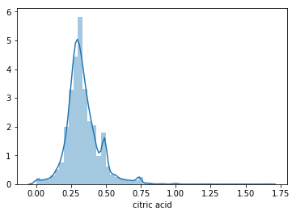

```python
sns.distplot(df['citric acid'])
```

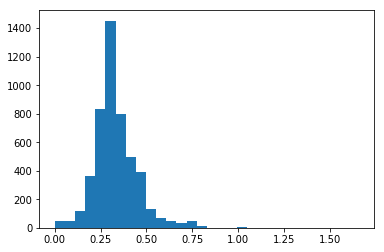

```python
plt.hist(df['citric acid'],bins=30)
```

1. Positive skewed
2. Outliers present
3. The citric acide value between 0.25 - 0.50 has the highest count.

## Residual sugar:Count plot

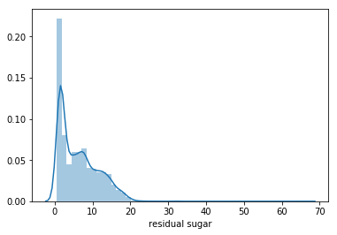

```python
sns.distplot(df['residual sugar'])
```

1. Higly positively skewed.
2. COunt reduces as the Amount of residual sugar increases.
3. Very few samples have high residual content.

## Chlorides : count plot

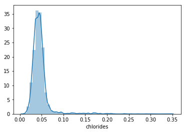

```python
sns.distplot(df['chlorides'])
```

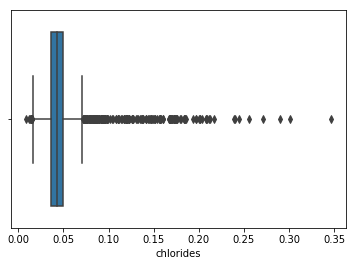

```python
sns.boxplot(df['chlorides'])
```

1. It is continuous in nature.
2. Higly positively skewed
3. Large number of outliers present.
4. Most of the wine samples included in the dataset have a chloride level of about 0.02 - 0.06 g / dm^3

## Free sulphir_di_oxide : countplot

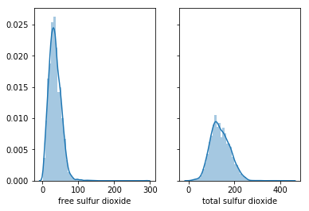

```python
fig,(ax1,ax2)=plt.subplots(ncols=2,sharey=True)
sns.distplot(df['free sulfur dioxide'], ax=ax1)
sns.distplot(df['total sulfur dioxide'],ax=ax2)
```

1. Both have positive skewness
2. Need to remove outliers.
3. We can see a spike distribution on free sulphur di oxide.

## PF : Count Plot

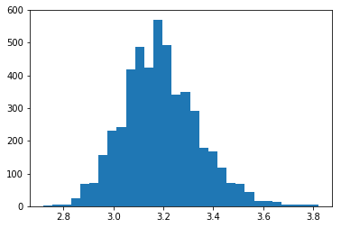

```python
plt.hist(df['pH'], bins=30)
```

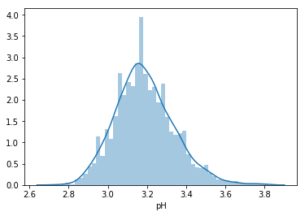

```python
sns.distplot(df['pH'])
```

1. Normal distribuitn.
2. Continuous in nature.
3. Mean and media mostly same.

## Density : CountPlot

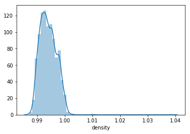

```python
sns.distplot(df['density'])
```

1. It is continuous in nature.
2. Outliers present.
3. density for most of the samples is observed to lie between 0.99 - 1.00 g / dm^3

## Alcohol : Countplot

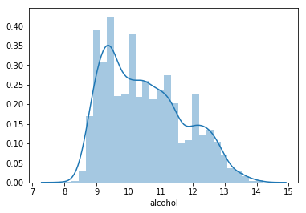

```python
sns.distplot(df['alcohol'])
```

1. A large number of samples are observed to have alcohol content around 9 - 10 by volume.
2. A few outliers are present.
3. Alcohol count decreases for higher quantity means higher qualites might have higher quantity alcohol.

## Suphates: Countplot

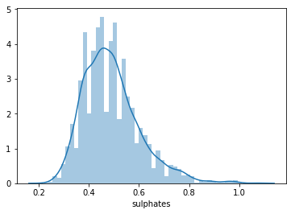

```python
sns.distplot(df['sulphates'])
```

1. It is continuous in nature.
2. There are outliers present.

## Inference from univariate analysis.

After plotting each of the graphs we can descide which are the strong features. The features with high mean and median are the one which affect the data the most. Those can be fixed cidity, residual sugar and pH. pH can also be a strong feature as it is the one which decides hte acidity content of. Alcohol content can play a major role in deciding the quality of the wine.

Furthure more strong features can be found using bivarite analysis.

### Bivariate Analysis

in this we plot graph between two features to get a realtion between them. First of all we plot the correlation graph.

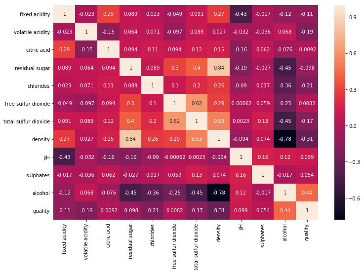

```python
plt.figure(figsize=(12,8))
sns.heatmap(df.corr(),annot=True)
```

Lest see the variables having strong correlation with the quality.

1. Chlorides
2. Density
3. Alcohol

## Quality vs Alcohol

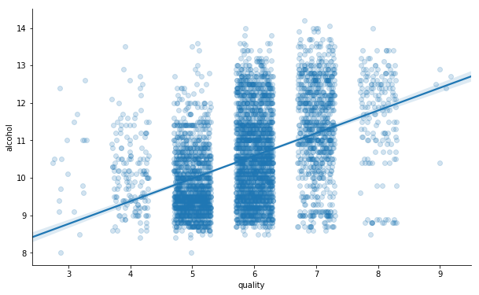

```python
plt.figure(figsize=(10,6))
sns.regplot(x='quality', y='alcohol', data=df, x_jitter=0.3, scatter_kws={'alpha':0.2})
sns.despine()
```

## Quality vs Density

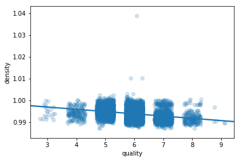

```python
sns.regplot(x='quality', y='density', data=df, x_jitter=0.3, scatter_kws={'alpha':0.2})
```

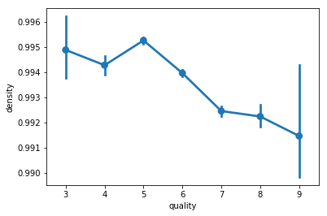

```python
sns.pointplot(x='quality', y='density', data=df, x_jitter=0.3, scatter_kws={'alpha':0.2})
```

We can infer following points from the above plot:

1. Top rated wine samples are seen having less density.
2. As we have seen in alcohol plotting, there is a continous trend, but in this the low quality wines dont have any continous trend. This means there is some other factor affecting the quality of low quality wines.

## Quality vs chlorides.

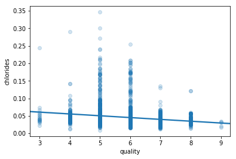

```python
sns.regplot(x='quality', y='chlorides', data=df, scatter_kws={'alpha':0.2})
```

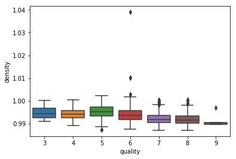

```python
sns.boxplot(x='quality', y='density', data=df)
```

## Alcohol vs Density

The graph between **alcohol** and **density** is plotted below

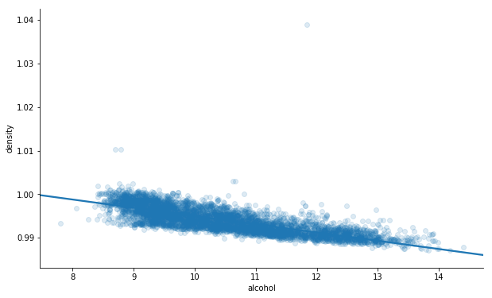

```python
plt.figure(figsize=(10,6))
sns.regplot(x='alcohol', y='density', data=df, x_jitter=0.2, scatter_kws={'alpha':0.15})
sns.despine()
```

These two are definitely correlated. More the density less the alcohol and vise versa.

So clearly Density and alcohol content are major features for our prediction. Now lets check how other features are related to these two.

## Density vs Residual Sugar

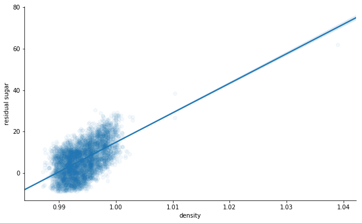

```python
plt.figure(figsize=(10,6))

sns.regplot(x='density', y='residual sugar', data=df, y_jitter=10, scatter_kws={'alpha':0.05})
sns.despine()
```

The wines with high amount of residual sugar are more dense.

## Inference from Bivariate data analysis.

The three main features were alcohol, density and chlorides. We can see that the the quality depends highly on alcohol content. And the alcohol content is inversly propostional to the density. Less density more the alcohol. One more feature that higly affect the data is of density and sugar. More residual sugar, more the density hence less alcohol content.

We have that density dont show much trend for low quality wines so we have to find more strog feature in multivariate analysis.

## Plot 1 between alcohol and density with quality as the factor

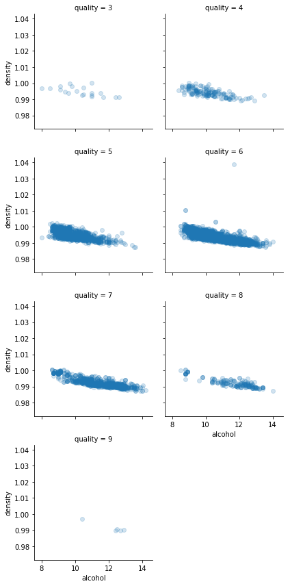

```python
grid= sns.FacetGrid(df, col='quality',col_wrap = 2)
grid.map(plt.scatter,'alcohol','density',alpha = 0.2)
```

## Plot 2 between alcohol and total sulphuric acid with quality as the factor

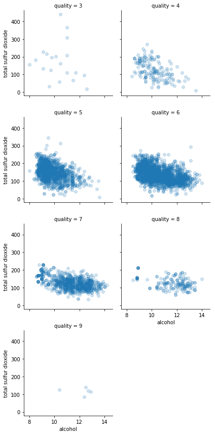

```python
grid= sns.FacetGrid(df, col='quality',col_wrap = 2)
grid.map(plt.scatter,'alcohol','total sulfur dioxide',alpha = 0.2)
```

## Plot 3 between density and residual sugar with quality as the factor.

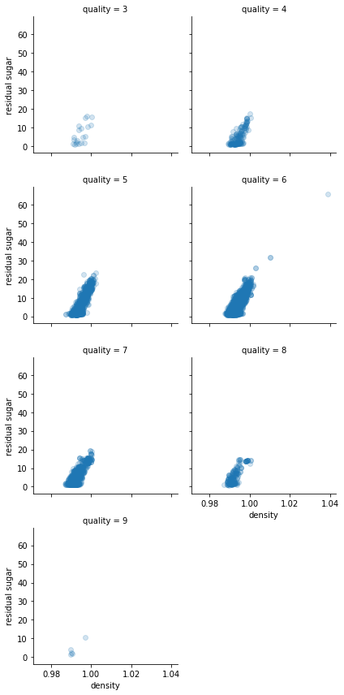

```python
grid= sns.FacetGrid(df, col='quality',col_wrap = 2)
grid.map(plt.scatter,'density','residual sugar',alpha = 0.2)
```

## Plot 4 between pH and total sulphur di oxide.

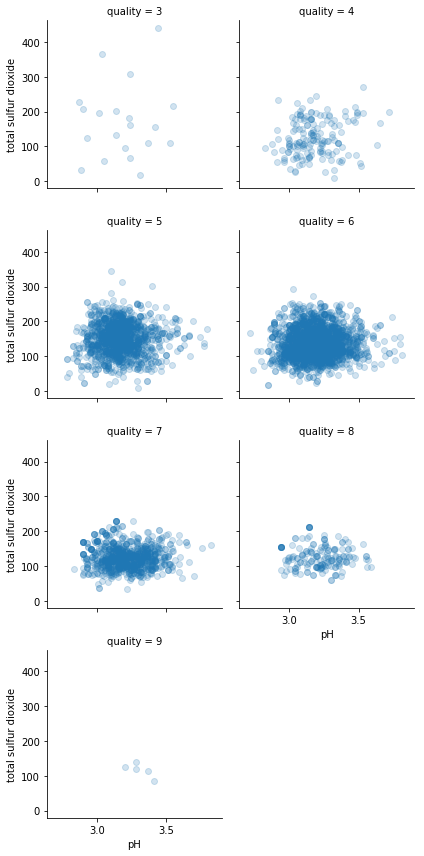

```python
grid= sns.FacetGrid(df, col='quality',col_wrap = 2)
grid.map(plt.scatter,'pH','total sulfur dioxide',alpha = 0.2)
```

From the above 4 plots, we infer that:

!!Plot 3 : The other main feature is the density which depeds on the residual sugar content. So less residual sugar, less density and more qaulity.

## Summary:

Problem faced:

1. overfitting of plots
2. Problem in finding good features
3. Problem in choosing the kind of plots.